# Project

### Project Name: Analysing Historical NBA Draft Data and Predicting Successful Player Careers

### Name: Sajal Nandi

### Student ID: 30111888

### University of South Wales

```python
import pandas as pd
```

```python
NBA = pd.read_csv("C:\\Users\\Sajal Nandi\\Downloads\\SN_30111888_Project\\30111888_NBA-Draft-Data.csv")
```

```python
NBA
```

|  | Rk | Pk | Draft Year | Player ID | Team | Player Name | College | Year | TOTG | TOTMP | ... | 3P% | FT% | MPPG | PTSPG | TRBPG | ASTPG | WS | WS/48 | BPM | VORP |
| --- | --- | --- | --- | --- | --- | --- | --- | --- | --- | --- | --- | --- | --- | --- | --- | --- | --- | --- | --- | --- | --- |
| 0 | 1 | 1 | 2000 | 200001 | NJN | Kenyon Martin | Cincinnati | 15 | 757 | 23134 | ... | 0.234 | 0.629 | 30.6 | 12.3 | 6.8 | 1.9 | 48.0 | 0.100 | 0.1 | 12.1 |
| 1 | 2 | 2 | 2000 | 200002 | VAN | Stromile Swift | LSU | 9 | 547 | 10804 | ... | 0.074 | 0.699 | 19.8 | 8.4 | 4.6 | 0.5 | 21.3 | 0.095 | -1.6 | 1.1 |
| 2 | 3 | 3 | 2000 | 200003 | CHI | Marcus Fizer | Iowa State | 6 | 289 | 6032 | ... | 0.191 | 0.691 | 20.9 | 9.6 | 4.6 | 1.2 | 2.7 | 0.022 | -3.7 | -2.6 |
| 3 | 4 | 4 | 2000 | 200004 | ORL | Mike Miller | Florida | 17 | 1032 | 27812 | ... | 0.407 | 0.769 | 26.9 | 10.6 | 4.2 | 2.6 | 60.7 | 0.105 | 0.8 | 19.8 |
| 4 | 5 | 5 | 2000 | 200005 | ATL | DerMarr Johnson | Cincinnati | 7 | 344 | 5930 | ... | 0.336 | 0.789 | 17.2 | 6.2 | 2.2 | 0.9 | 6.4 | 0.052 | -1.6 | 0.6 |
| ... | ... | ... | ... | ... | ... | ... | ... | ... | ... | ... | ... | ... | ... | ... | ... | ... | ... | ... | ... | ... | ... |
| 418 | 43 | 43 | 2010 | 201043 | LAC | Willie Warren | Oklahoma | 1 | 19 | 134 | ... | 0.333 | 0.750 | 7.1 | 1.9 | 0.6 | 1.4 | 0.2 | 0.065 | -2.7 | 0.0 |
| 419 | 44 | 44 | 2010 | 201044 | UTA | Jeremy Evans | Western Kentucky | 7 | 250 | 2626 | ... | 0.231 | 0.687 | 10.5 | 3.5 | 2.6 | 0.4 | 8.2 | 0.150 | 0.9 | 1.9 |
| 420 | 45 | 45 | 2010 | 201045 | MIN | Hamady N'Diaye | Rutgers University | 3 | 33 | 157 | ... | NaN | 0.462 | 4.8 | 0.6 | 0.8 | 0.1 | 0.0 | 0.013 | -7.3 | -0.2 |
| 421 | 46 | 46 | 2010 | 201046 | IND | Ryan Reid | Florida State | 1 | 5 | 17 | ... | NaN | NaN | 3.4 | 1.6 | 0.4 | 0.0 | 0.1 | 0.142 | -2.0 | 0.0 |
| 422 | 47 | 47 | 2010 | 201047 | LAL | Derrick Caracter | Texas-El Paso | 1 | 41 | 215 | ... | NaN | 0.739 | 5.2 | 2.0 | 1.0 | 0.2 | 0.3 | 0.057 | -7.1 | -0.3 |

423 rows × 24 columns

```python
# In the above data set, the empty cells are shown as NAN values.
# Finding Columnwise Empty Cell
empty_cells = NBA.isna().sum() + (NBA == '').sum()
```

```python
empty_cells
```

```
Rk              0
Pk              0
Draft Year      0
Player ID       0
Team            0
Player Name     0
College         0
Year            0
TOTG            0
TOTMP           0
TOTPTS          0
TRB             0
TOTAST          0
FG%             1
3P%            39
FT%             8
MPPG            0
PTSPG           0
TRBPG           0
ASTPG           0
WS              0
WS/48           0
BPM             0
VORP            0
dtype: int64
```

```python
# Replace empty cells with NAN values
import numpy as np
NBA.replace('', np.nan, inplace=True)
```

```python
# Replacing NaN values with zero
NBA.fillna(0, inplace=True)
```

```python
# Checking empty cells columnwise again
empty_cells = NBA.isna().sum() + (NBA == '').sum()
```

```python
empty_cells
```

```
Rk             0
Pk             0
Draft Year     0
Player ID      0
Team           0
Player Name    0
College        0
Year           0
TOTG           0
TOTMP          0
TOTPTS         0
TRB            0
TOTAST         0
FG%            0
3P%            0
FT%            0
MPPG           0
PTSPG          0
TRBPG          0
ASTPG          0
WS             0
WS/48          0
BPM            0
VORP           0
dtype: int64
```

```python
X_NBA_Original = NBA.drop(["Rk", "Pk", "Draft Year", "Team", "Player Name", "College", "Year", "WS", "WS/48", "VORP", "BPM"], axis=1)

# We have droped "VORP" from the data set because the "BPM" is used to calculate VORP. If I use the feature "VORP", our model will mainly calculate
# BPM from VORP, because of which we will not understand the proper importance of other features in predicting BPM.
```

```python
X_NBA_Original
```

|  | Player ID | TOTG | TOTMP | TOTPTS | TRB | TOTAST | FG% | 3P% | FT% | MPPG | PTSPG | TRBPG | ASTPG |
| --- | --- | --- | --- | --- | --- | --- | --- | --- | --- | --- | --- | --- | --- |
| 0 | 200001 | 757 | 23134 | 9325 | 5159 | 1439 | 0.483 | 0.234 | 0.629 | 30.6 | 12.3 | 6.8 | 1.9 |
| 1 | 200002 | 547 | 10804 | 4582 | 2535 | 275 | 0.473 | 0.074 | 0.699 | 19.8 | 8.4 | 4.6 | 0.5 |
| 2 | 200003 | 289 | 6032 | 2782 | 1340 | 352 | 0.435 | 0.191 | 0.691 | 20.9 | 9.6 | 4.6 | 1.2 |
| 3 | 200004 | 1032 | 27812 | 10973 | 4376 | 2666 | 0.459 | 0.407 | 0.769 | 26.9 | 10.6 | 4.2 | 2.6 |
| 4 | 200005 | 344 | 5930 | 2121 | 769 | 304 | 0.411 | 0.336 | 0.789 | 17.2 | 6.2 | 2.2 | 0.9 |
| ... | ... | ... | ... | ... | ... | ... | ... | ... | ... | ... | ... | ... | ... |
| 418 | 201043 | 19 | 134 | 37 | 12 | 27 | 0.371 | 0.333 | 0.750 | 7.1 | 1.9 | 0.6 | 1.4 |
| 419 | 201044 | 250 | 2626 | 879 | 641 | 107 | 0.569 | 0.231 | 0.687 | 10.5 | 3.5 | 2.6 | 0.4 |
| 420 | 201045 | 33 | 157 | 20 | 25 | 3 | 0.467 | 0.000 | 0.462 | 4.8 | 0.6 | 0.8 | 0.1 |
| 421 | 201046 | 5 | 17 | 8 | 2 | 0 | 0.800 | 0.000 | 0.000 | 3.4 | 1.6 | 0.4 | 0.0 |
| 422 | 201047 | 41 | 215 | 81 | 43 | 7 | 0.485 | 0.000 | 0.739 | 5.2 | 2.0 | 1.0 | 0.2 |

423 rows × 13 columns

```python
X_NBA_ONE = pd.DataFrame(X_NBA_Original) #Making a new data set using the original nba data
```

```python
X_NBA_ONE
```

|  | Player ID | TOTG | TOTMP | TOTPTS | TRB | TOTAST | FG% | 3P% | FT% | MPPG | PTSPG | TRBPG | ASTPG |
| --- | --- | --- | --- | --- | --- | --- | --- | --- | --- | --- | --- | --- | --- |
| 0 | 200001 | 757 | 23134 | 9325 | 5159 | 1439 | 0.483 | 0.234 | 0.629 | 30.6 | 12.3 | 6.8 | 1.9 |
| 1 | 200002 | 547 | 10804 | 4582 | 2535 | 275 | 0.473 | 0.074 | 0.699 | 19.8 | 8.4 | 4.6 | 0.5 |
| 2 | 200003 | 289 | 6032 | 2782 | 1340 | 352 | 0.435 | 0.191 | 0.691 | 20.9 | 9.6 | 4.6 | 1.2 |
| 3 | 200004 | 1032 | 27812 | 10973 | 4376 | 2666 | 0.459 | 0.407 | 0.769 | 26.9 | 10.6 | 4.2 | 2.6 |
| 4 | 200005 | 344 | 5930 | 2121 | 769 | 304 | 0.411 | 0.336 | 0.789 | 17.2 | 6.2 | 2.2 | 0.9 |
| ... | ... | ... | ... | ... | ... | ... | ... | ... | ... | ... | ... | ... | ... |
| 418 | 201043 | 19 | 134 | 37 | 12 | 27 | 0.371 | 0.333 | 0.750 | 7.1 | 1.9 | 0.6 | 1.4 |
| 419 | 201044 | 250 | 2626 | 879 | 641 | 107 | 0.569 | 0.231 | 0.687 | 10.5 | 3.5 | 2.6 | 0.4 |
| 420 | 201045 | 33 | 157 | 20 | 25 | 3 | 0.467 | 0.000 | 0.462 | 4.8 | 0.6 | 0.8 | 0.1 |
| 421 | 201046 | 5 | 17 | 8 | 2 | 0 | 0.800 | 0.000 | 0.000 | 3.4 | 1.6 | 0.4 | 0.0 |
| 422 | 201047 | 41 | 215 | 81 | 43 | 7 | 0.485 | 0.000 | 0.739 | 5.2 | 2.0 | 1.0 | 0.2 |

423 rows × 13 columns

```python
X_NBA_ONE = X_NBA_ONE.drop(["Player ID"], axis=1)
```

```python
X_NBA_ONE # This data set is not used for merging with other data set.
```

|  | TOTG | TOTMP | TOTPTS | TRB | TOTAST | FG% | 3P% | FT% | MPPG | PTSPG | TRBPG | ASTPG |
| --- | --- | --- | --- | --- | --- | --- | --- | --- | --- | --- | --- | --- |
| 0 | 757 | 23134 | 9325 | 5159 | 1439 | 0.483 | 0.234 | 0.629 | 30.6 | 12.3 | 6.8 | 1.9 |
| 1 | 547 | 10804 | 4582 | 2535 | 275 | 0.473 | 0.074 | 0.699 | 19.8 | 8.4 | 4.6 | 0.5 |
| 2 | 289 | 6032 | 2782 | 1340 | 352 | 0.435 | 0.191 | 0.691 | 20.9 | 9.6 | 4.6 | 1.2 |
| 3 | 1032 | 27812 | 10973 | 4376 | 2666 | 0.459 | 0.407 | 0.769 | 26.9 | 10.6 | 4.2 | 2.6 |
| 4 | 344 | 5930 | 2121 | 769 | 304 | 0.411 | 0.336 | 0.789 | 17.2 | 6.2 | 2.2 | 0.9 |
| ... | ... | ... | ... | ... | ... | ... | ... | ... | ... | ... | ... | ... |
| 418 | 19 | 134 | 37 | 12 | 27 | 0.371 | 0.333 | 0.750 | 7.1 | 1.9 | 0.6 | 1.4 |
| 419 | 250 | 2626 | 879 | 641 | 107 | 0.569 | 0.231 | 0.687 | 10.5 | 3.5 | 2.6 | 0.4 |
| 420 | 33 | 157 | 20 | 25 | 3 | 0.467 | 0.000 | 0.462 | 4.8 | 0.6 | 0.8 | 0.1 |
| 421 | 5 | 17 | 8 | 2 | 0 | 0.800 | 0.000 | 0.000 | 3.4 | 1.6 | 0.4 | 0.0 |
| 422 | 41 | 215 | 81 | 43 | 7 | 0.485 | 0.000 | 0.739 | 5.2 | 2.0 | 1.0 | 0.2 |

423 rows × 12 columns

```python
y_nba_o = NBA["BPM"]
```

```python
y_nba_o
```

```
0      0.1
1     -1.6
2     -3.7
3      0.8
4     -1.6
      ...
418   -2.7
419    0.9
420   -7.3
421   -2.0
422   -7.1
Name: BPM, Length: 423, dtype: float64
```

```python
y_nba_o = pd.DataFrame(y_nba_o)
```

```python
y_nba_o # Original target variable before being split
```

|  | BPM |
| --- | --- |
| 0 | 0.1 |
| 1 | -1.6 |
| 2 | -3.7 |
| 3 | 0.8 |
| 4 | -1.6 |
| ... | ... |
| 418 | -2.7 |
| 419 | 0.9 |
| 420 | -7.3 |
| 421 | -2.0 |
| 422 | -7.1 |

423 rows × 1 columns

```python
y_NBA_ONE = pd.DataFrame(y_nba_o) # Making a new target variable using the original target variable
```

```python
y_NBA_ONE
```

|  | BPM |
| --- | --- |
| 0 | 0.1 |
| 1 | -1.6 |
| 2 | -3.7 |
| 3 | 0.8 |
| 4 | -1.6 |
| ... | ... |
| 418 | -2.7 |
| 419 | 0.9 |
| 420 | -7.3 |
| 421 | -2.0 |
| 422 | -7.1 |

423 rows × 1 columns

```python
import matplotlib.pyplot as plt
import seaborn as sns
```

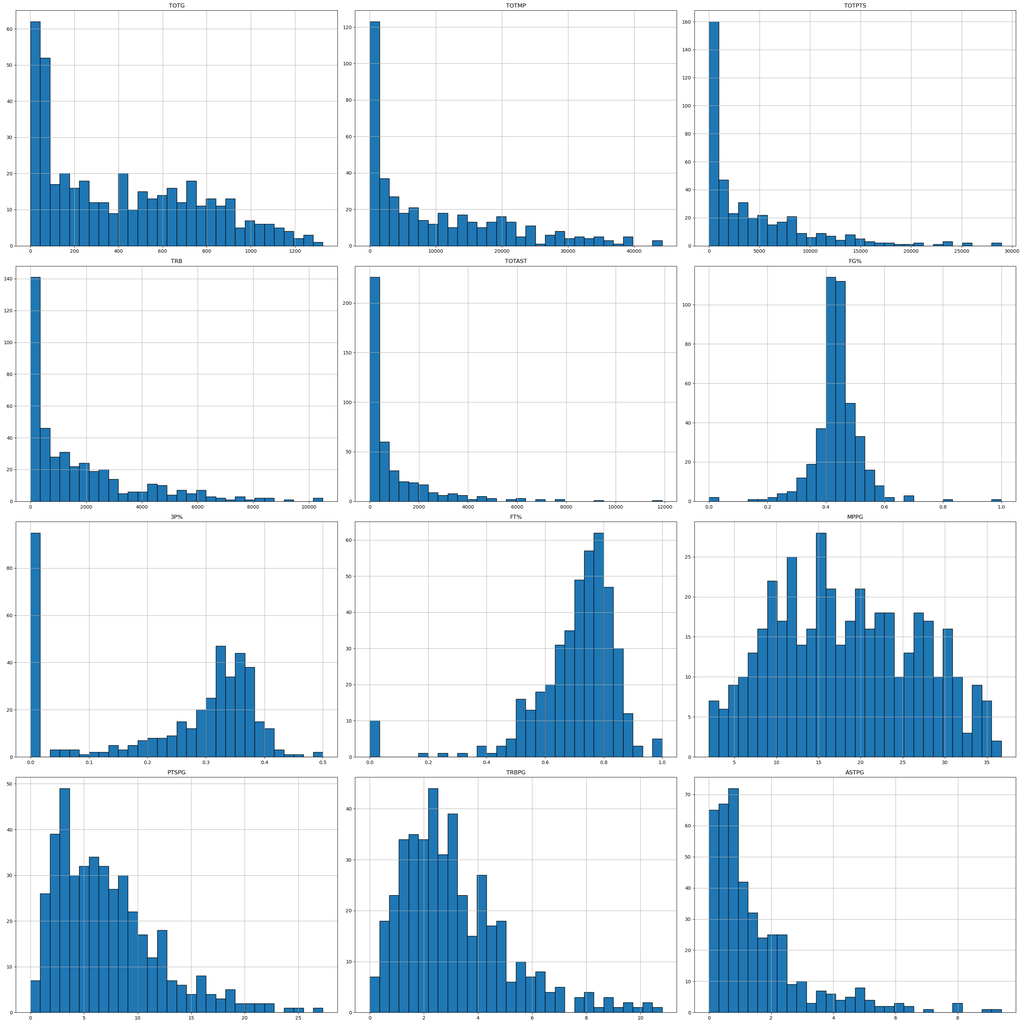

```python
# Set the figure size to handle all features
X_NBA_ONE.hist(figsize=(30, 30), bins=30, edgecolor='black')

# Display the plots
plt.tight_layout()  # Adjust subplots to fit into figure area
plt.show()
```

```python
skewness_per_column = X_NBA_ONE.skew()
```

```python
skewness_per_column
```

```
TOTG      0.517557
TOTMP     1.044943
TOTPTS    1.823226
TRB       1.589068
TOTAST    2.941461
FG%       0.102526
3P%      -0.723551
FT%      -2.237356
MPPG      0.152056
PTSPG     1.172282
TRBPG     1.206813
ASTPG     2.027343
dtype: float64
```

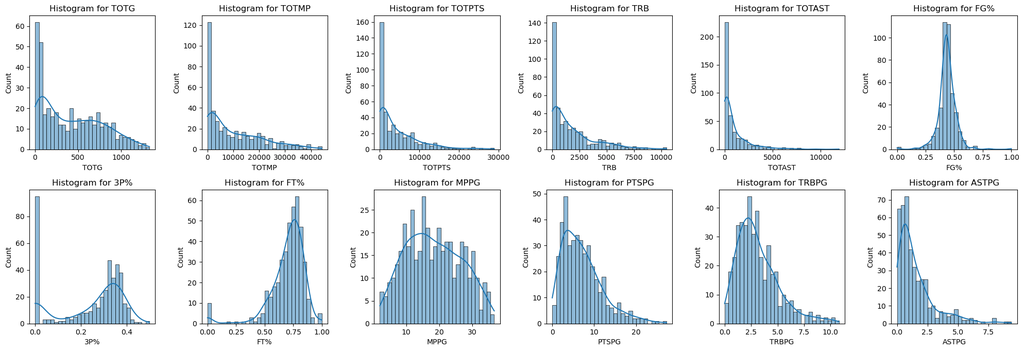

```python
# Set up the plot grid
num_columns = X_NBA_ONE.select_dtypes(include=['float64', 'int64']).columns  # Only numeric features
plt.figure(figsize=(20, 20))

for i, column in enumerate(num_columns, 1):
    plt.subplot(6, 6, i)  # Adjust 6x6 grid based on the number of features
    sns.histplot(X_NBA_ONE[column], kde=True, bins=30, edgecolor='black')
    plt.title(f'Histogram for {column}')

plt.tight_layout()
plt.show()
```

```python
# Spliting NBA draft data set
from sklearn.model_selection import train_test_split
X_NBA_ONE_train, X_NBA_ONE_test, y_NBA_ONE_train, y_NBA_ONE_test = train_test_split(X_NBA_ONE, y_NBA_ONE, test_size=0.2, random_state=42)
```

#### Creating a baseline model with mean and median for the regression tasks

```python
from sklearn.metrics import r2_score
```

```python
# Predicting the mean BPM as the baseline
baseline_prediction_mean = np.mean(y_NBA_ONE_train)
```

```python
# Apply baseline prediction (mean) to the test set
y_pred_baseline_mean = [baseline_prediction_mean] * len(y_NBA_ONE_test)
```

```python
# Evaluate the baseline model using mean squared error and R-squared
mse_baseline_mean = mean_squared_error(y_NBA_ONE_test, y_pred_baseline_mean)
r2_baseline_mean = r2_score(y_NBA_ONE_test, y_pred_baseline_mean)
```

```python
print(f"Baseline Model (Mean):\n Mean Squared Error: {mse_baseline_mean}\n R-squared: {r2_baseline_mean}\n")
```

```
Baseline Model (Mean):
 Mean Squared Error: 13.02904968828328
 R-squared: -0.007364885998565329
```

```python
#Predicting the median BPM as the baseline
baseline_prediction_median = np.median(y_NBA_ONE_train)
```

```python
# Apply baseline prediction (median) to the test set
y_pred_baseline_median = [baseline_prediction_median] * len(y_NBA_ONE_test)
```

```python
mse_baseline_median = mean_squared_error(y_NBA_ONE_test, y_pred_baseline_median)
r2_baseline_median = r2_score(y_NBA_ONE_test, y_pred_baseline_median)
```

```python
print(f"Baseline Model (Median):\n Mean Squared Error: {mse_baseline_median}\n R-squared: {r2_baseline_median}\n")
```

```
Baseline Model (Median):
 Mean Squared Error: 13.28258823529412
 R-squared: -0.026967684024233662
```

## Random Forest Regressor for just only nba draft data

```python
from sklearn.ensemble import RandomForestRegressor
from sklearn.model_selection import train_test_split
from sklearn.metrics import mean_squared_error, r2_score
import pandas as pd
import numpy as np
```

```python
# Initializing the random forest regressor with 100 trees
rf = RandomForestRegressor(n_estimators=100, random_state=42)
```

```python
# Fitting the model on training data
rf.fit(X_NBA_ONE_train, y_NBA_ONE_train)
```

```
C:\Users\Sajal Nandi\AppData\Local\Temp\ipykernel_15212\2020363758.py:2: DataConversionWarning: A column-vector y was passed when a 1d array was expected. Please change the shape of y to (n_samples,), for example using ravel().
  rf.fit(X_NBA_ONE_train, y_NBA_ONE_train)
```

```
RandomForestRegressor(random_state=42)
```

```python
# Predicting the BPM values for the test set
y_pred_rf = rf.predict(X_NBA_ONE_test)   #rf means Random Forest
```

```python
# Evaluating the model
mse_rf = mean_squared_error(y_NBA_ONE_test, y_pred_rf)
r2_rf = r2_score(y_NBA_ONE_test, y_pred_rf)

print(f'Mean Squared Error: {mse_rf}')
print(f'R-squared: {r2_rf}')
```

```
Mean Squared Error: 2.9487490823529408
R-squared: 0.7720120535073165
```

```python
# Hyperparameter Tuning for the Random Forest Regressor Model
from sklearn.model_selection import GridSearchCV
```

```python
param_grid = {
    'n_estimators': [100, 200, 300],
    'max_depth': [10, 20, 30],
    'min_samples_split': [2, 5, 10]
}

grid_search = GridSearchCV(estimator=rf, param_grid=param_grid, cv=5)
grid_search.fit(X_NBA_ONE_train, y_NBA_ONE_train)

print(grid_search.best_params_)
```

[output not shown]

[output cut: 246 more lines]

```
{'max_depth': 20, 'min_samples_split': 10, 'n_estimators': 100}
```

```python
# Initializing the random forest regressor with new parameters
rf_nba_tune = RandomForestRegressor(n_estimators=100, max_depth=20, min_samples_split=10, random_state=42)
```

```python
# Fitting the model on training data
rf_nba_tune.fit(X_NBA_ONE_train, y_NBA_ONE_train)
```

```
C:\Users\Sajal Nandi\AppData\Local\Temp\ipykernel_15212\1637844009.py:2: DataConversionWarning: A column-vector y was passed when a 1d array was expected. Please change the shape of y to (n_samples,), for example using ravel().
  rf_nba_tune.fit(X_NBA_ONE_train, y_NBA_ONE_train)
```

```
RandomForestRegressor(max_depth=20, min_samples_split=10, random_state=42)
```

```python
# Predicting the BPM values for the test set
y_pred_rf_nba_tune = rf_nba_tune.predict(X_NBA_ONE_test)   #rf means Random Forest
```

```python
# Evaluating the model
mse_rf_nba_tune = mean_squared_error(y_NBA_ONE_test, y_pred_rf_nba_tune)
r2_rf_nba_tune = r2_score(y_NBA_ONE_test, y_pred_rf_nba_tune)

print(f'Mean Squared Error: {mse_rf_nba_tune}')
print(f'R-squared: {r2_rf_nba_tune}')
```

```
Mean Squared Error: 2.892219974707688
R-squared: 0.7763827052003459
```

```python
# The Random Forest Regressor model has performed better with tuned hyparparameters.
```

## XGBoost Model for NBA data set

```python
# Split NBA draft data set names: X_NBA_ONE_train, X_NBA_ONE_test, y_NBA_ONE_train, y_NBA_ONE_test
```

```python
import xgboost as xgb
from sklearn.model_selection import train_test_split
from sklearn.preprocessing import StandardScaler
from sklearn.metrics import mean_squared_error, r2_score
import pandas as pd
import numpy as np
```

```python
# Initialize the scaler
scaler = StandardScaler()
```

```python
# Scale the training data
X_train_scaled_nba_boost = scaler.fit_transform(X_NBA_ONE_train)

# Scale the test data
X_test_scaled_nba_boost = scaler.transform(X_NBA_ONE_test)
```

```python
# Initialize the XGBoost regressor
xgb_model_nba = xgb.XGBRegressor(
    n_estimators=100,  # Number of boosting rounds (trees)
    learning_rate=0.1, # Shrinkage rate
    max_depth=3,       # Maximum depth of trees
    subsample=0.8,     # Fraction of samples used for fitting individual base learners
    random_state=42
)
```

```python
xgb_model_nba.fit(X_train_scaled_nba_boost, y_NBA_ONE_train)
```

```
XGBRegressor(base_score=None, booster=None, callbacks=None,
             colsample_bylevel=None, colsample_bynode=None,
             colsample_bytree=None, device=None, early_stopping_rounds=None,
             enable_categorical=False, eval_metric=None, feature_types=None,
             gamma=None, grow_policy=None, importance_type=None,
             interaction_constraints=None, learning_rate=0.1, max_bin=None,
             max_cat_threshold=None, max_cat_to_onehot=None,
             max_delta_step=None, max_depth=3, max_leaves=None,
             min_child_weight=None, missing=nan, monotone_constraints=None,
             multi_strategy=None, n_estimators=100, n_jobs=None,
             num_parallel_tree=None, random_state=42, ...)
```

```python
# Predict BPM values for the test set
y_pred_boot_nba = xgb_model_nba.predict(X_test_scaled_nba_boost)
```

```python
# Evaluate the model
mse = mean_squared_error(y_NBA_ONE_test, y_pred_boot_nba)
r2 = r2_score(y_NBA_ONE_test, y_pred_boot_nba)
```

```python
print(f'Mean Squared Error: {mse}')
print(f'R-squared: {r2}')
```

```
Mean Squared Error: 2.8455565312523414
R-squared: 0.7799905749622494
```

```python
# Hyperparameter Tuning

from sklearn.model_selection import GridSearchCV

# Define the parameter grid
param_grid = {
    'n_estimators': [100, 200, 300],
    'learning_rate': [0.01, 0.1, 0.2],
    'max_depth': [3, 5, 7],
    'subsample': [0.8, 1.0]
}

# Initialize GridSearchCV with XGBRegressor
grid_search = GridSearchCV(estimator=xgb.XGBRegressor(random_state=42), param_grid=param_grid, cv=5, scoring='r2')

# Fit the grid search to the scaled training data
grid_search.fit(X_train_scaled_nba_boost, y_NBA_ONE_train)

# Print the best parameters
print(f'Best parameters: {grid_search.best_params_}')
```

```
Best parameters: {'learning_rate': 0.2, 'max_depth': 3, 'n_estimators': 100, 'subsample': 0.8}
```

```python
# Use the best model for prediction
best_model = grid_search.best_estimator_
y_pred_best = best_model.predict(X_test_scaled_nba_boost)
```

```python
# Evaluate the best model
mse_best = mean_squared_error(y_NBA_ONE_test, y_pred_best)
r2_best = r2_score(y_NBA_ONE_test, y_pred_best)

print(f'Best Mean Squared Error: {mse_best}')
print(f'Best R-squared: {r2_best}')
```

```
Best Mean Squared Error: 2.9560101170515907
Best R-squared: 0.7714506532850105
```

```python
# The model without hyperparameters performed better.
```

## Artificial Neural Network (ANN) for NBA Draft Data

```python
# Split NBA draft data set names: X_NBA_ONE_train, X_NBA_ONE_test, y_NBA_ONE_train, y_NBA_ONE_test
```

```python
import numpy as np
import pandas as pd
from sklearn.model_selection import train_test_split
from sklearn.preprocessing import StandardScaler
from sklearn.metrics import mean_squared_error, r2_score
import tensorflow as tf
from tensorflow.keras.models import Sequential
from tensorflow.keras.layers import Dense
from tensorflow.keras.optimizers import Adam
```

```python
# Initialize the standard scaler
scaler = StandardScaler()
```

```python
# Scale the training data
X_train_scaled_nba_ann = scaler.fit_transform(X_NBA_ONE_train)

# Scale the test data
X_test_scaled_nba_ann = scaler.transform(X_NBA_ONE_test)
```

```python
# Initialize the model
model_nba_ann = Sequential()

# Input layer and first hidden layer with 64 neurons and ReLU activation
model_nba_ann.add(Dense(64, input_dim=X_train_scaled_nba_ann.shape[1], activation='relu'))

# Additional hidden layers
model_nba_ann.add(Dense(128, activation='relu'))
model_nba_ann.add(Dense(64, activation='relu'))

# Output layer with a single neuron (since this is a regression problem)
model_nba_ann.add(Dense(1, activation='linear'))

# Compile the model with mean squared error loss and the Adam optimizer
model_nba_ann.compile(optimizer=Adam(learning_rate=0.001), loss='mean_squared_error', metrics=['mse'])
```

```python
# Train the model
history = model_nba_ann.fit(X_train_scaled_nba_ann, y_NBA_ONE_train, validation_split=0.2, epochs=100, batch_size=32, verbose=1)
```

```python
# Predict BPM values for the test set
y_pred_nba_ann = model_nba_ann.predict(X_test_scaled_nba_ann)

# Evaluate the model's performance
mse_nba_ann = mean_squared_error(y_NBA_ONE_test, y_pred_nba_ann)
r2_nba_ann = r2_score(y_NBA_ONE_test, y_pred_nba_ann)

print(f'Mean Squared Error: {mse_nba_ann}')
print(f'R-squared: {r2_nba_ann}')
```

```
Mean Squared Error: 4.138562800753171
R-squared: 0.680019422465804
```

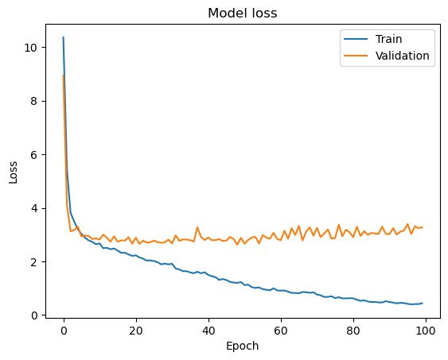

```python
# Visualizing Training history
import matplotlib.pyplot as plt

# Plot training & validation loss values
plt.plot(history.history['loss'])
plt.plot(history.history['val_loss'])
plt.title('Model loss')
plt.xlabel('Epoch')
plt.ylabel('Loss')
plt.legend(['Train', 'Validation'], loc='upper right')
plt.show()
```

```python
# The above model overfits.
```

```python
# We further use L2 Regularization to see whether we can make this model even a better model or not.

from keras.regularizers import l2

# Define the neural network architecture with L2 regularization
model_nba_ann_l2 = Sequential()

# Input layer and first hidden layer with 64 neurons, ReLU activation, and L2 regularization
model_nba_ann_l2.add(Dense(64, input_dim=X_train_scaled_nba_ann.shape[1], activation='relu',
                kernel_regularizer=l2(0.01)))  # L2 regularization with factor 0.01

# Additional hidden layers with L2 regularization
model_nba_ann_l2.add(Dense(128, activation='relu', kernel_regularizer=l2(0.01)))
model_nba_ann_l2.add(Dense(64, activation='relu', kernel_regularizer=l2(0.01)))

# Output layer with 1 neuron (for regression)
model_nba_ann_l2.add(Dense(1, activation='linear'))

# Compile the model
model_nba_ann_l2.compile(optimizer=Adam(learning_rate=0.001), loss='mean_squared_error', metrics=['mse'])
```

```python
# Train the model
history_l2 = model_nba_ann_l2.fit(X_train_scaled_nba_ann, y_NBA_ONE_train, validation_split=0.2, epochs=100, batch_size=32, verbose=1)
```

```python
# Predict BPM values for the test set
y_pred_nba_ann_l2 = model_nba_ann_l2.predict(X_test_scaled_nba_ann)

# Evaluate the model's performance
mse_nba_ann_l2 = mean_squared_error(y_NBA_ONE_test, y_pred_nba_ann_l2)
r2_nba_ann_l2 = r2_score(y_NBA_ONE_test, y_pred_nba_ann_l2)

print(f'Mean Squared Error: {mse_nba_ann_l2}')
print(f'R-squared: {r2_nba_ann_l2}')
```

```
Mean Squared Error: 4.615045530963616
R-squared: 0.6431792857956388
```

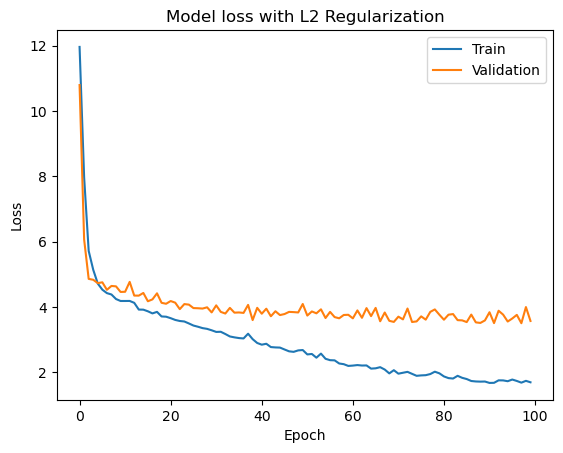

```python
# Visualizing Training history
import matplotlib.pyplot as plt

# Plot training & validation loss values
plt.plot(history_l2.history['loss'])
plt.plot(history_l2.history['val_loss'])
plt.title('Model loss with L2 Regularization')
plt.xlabel('Epoch')
plt.ylabel('Loss')
plt.legend(['Train', 'Validation'], loc='upper right')
plt.show()
```

```python
# From the above plot, we can say that the model overfits.
```

## Deep Neural Network (DNN) for NBA data

```python
# Split NBA draft data set names: X_NBA_ONE_train, X_NBA_ONE_test, y_NBA_ONE_train, y_NBA_ONE_test
```

```python
import numpy as np
import pandas as pd
from sklearn.model_selection import train_test_split
from sklearn.preprocessing import StandardScaler
from sklearn.metrics import mean_squared_error, r2_score
import tensorflow as tf
from tensorflow.keras.models import Sequential
from tensorflow.keras.layers import Dense, Dropout
from tensorflow.keras.optimizers import Adam
```

```python
# Initialize the standard scaler
scaler = StandardScaler()

# Scale the training data
X_train_scaled_nba_dnn = scaler.fit_transform(X_NBA_ONE_train)

# Scale the test data
X_test_scaled_nba_dnn = scaler.transform(X_NBA_ONE_test)
```

```python
# Initialize the model
model_nba_dnn = Sequential()

# Input layer and first hidden layer with 64 neurons and ReLU activation
model_nba_dnn.add(Dense(64, input_dim=X_train_scaled_nba_dnn.shape[1], activation='relu'))

# Additional hidden layers
model_nba_dnn.add(Dense(128, activation='relu'))
model_nba_dnn.add(Dropout(0.3))  # Dropout layer to prevent overfitting
model_nba_dnn.add(Dense(64, activation='relu'))

# Output layer with a single neuron (since this is a regression problem)
model_nba_dnn.add(Dense(1, activation='linear'))

# Compile the model with mean squared error loss and the Adam optimizer
model_nba_dnn.compile(optimizer=Adam(learning_rate=0.001), loss='mean_squared_error', metrics=['mse'])
```

```python
# Train the model
history = model_nba_dnn.fit(X_train_scaled_nba_dnn, y_NBA_ONE_train, validation_split=0.2, epochs=100, batch_size=32, verbose=1)
```

```python
# Predict BPM values for the test set
y_pred_nba_dnn = model_nba_dnn.predict(X_test_scaled_nba_dnn)

# Evaluate the model's performance
mse_nba_dnn = mean_squared_error(y_NBA_ONE_test, y_pred_nba_dnn)
r2_nba_dnn = r2_score(y_NBA_ONE_test, y_pred_nba_dnn)

print(f'Mean Squared Error: {mse_nba_dnn}')
print(f'R-squared: {r2_nba_dnn}')
```

```
Mean Squared Error: 5.180243291255743
R-squared: 0.5994799837755278
```

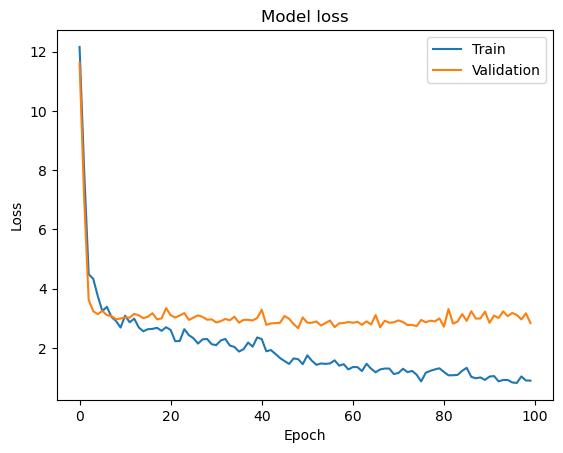

```python
import matplotlib.pyplot as plt

# Plot training & validation loss values
plt.plot(history.history['loss'])
plt.plot(history.history['val_loss'])
plt.title('Model loss')
plt.xlabel('Epoch')
plt.ylabel('Loss')
plt.legend(['Train', 'Validation'], loc='upper right')
plt.show()
```

```python
# From the above plot, we can say that the model overfits.
```

```python
import tensorflow as tf
from tensorflow.keras import layers, models, regularizers

# Define the model architecture with L2 regularization
model_nba_dnn_l2 = models.Sequential()

# Input layer and first hidden layer with 64 neurons, ReLU activation, and L2 regularization
model_nba_dnn_l2.add(Dense(64, input_dim=X_train_scaled_nba_dnn.shape[1], activation='relu',
                kernel_regularizer=l2(0.001)))  # L2 regularization with factor 0.001

# Hidden layers with L2 regularization
model_nba_dnn_l2.add(layers.Dense(128, activation='relu', kernel_regularizer=regularizers.l2(0.001)))
model_nba_dnn_l2.add(layers.Dense(64, activation='relu', kernel_regularizer=regularizers.l2(0.001)))
model_nba_dnn_l2.add(layers.Dense(32, activation='relu', kernel_regularizer=regularizers.l2(0.001)))

# Output layer for regression (for predicting BPM)
model_nba_dnn_l2.add(layers.Dense(1))  # Single output for regression

# Compile the model
model_nba_dnn_l2.compile(optimizer='adam',
              loss='mean_squared_error',  # For regression
              metrics=['mae'])  # Mean Absolute Error as an additional metric
```

```python
# Train the model
history_l2 = model_nba_dnn_l2.fit(X_train_scaled_nba_dnn, y_NBA_ONE_train, validation_split=0.2, epochs=100, batch_size=32, verbose=1)
```

```python
# Predict BPM values for the test set
y_pred_nba_dnn_l2 = model_nba_dnn_l2.predict(X_test_scaled_nba_dnn)

# Evaluate the model's performance
mse_nba_dnn_l2 = mean_squared_error(y_NBA_ONE_test, y_pred_nba_dnn_l2)
r2_nba_dnn_l2 = r2_score(y_NBA_ONE_test, y_pred_nba_dnn_l2)

print(f'Mean Squared Error: {mse_nba_dnn_l2}')
print(f'R-squared: {r2_nba_dnn_l2}')
```

```
Mean Squared Error: 6.39187580856116
R-squared: 0.5058003922574186
```

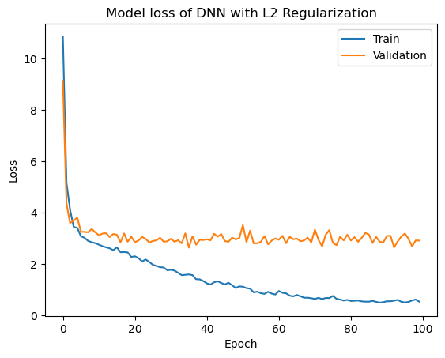

```python
import matplotlib.pyplot as plt

# Plot training & validation loss values
plt.plot(history_l2.history['loss'])
plt.plot(history_l2.history['val_loss'])
plt.title('Model loss of DNN with L2 Regularization')
plt.xlabel('Epoch')
plt.ylabel('Loss')
plt.legend(['Train', 'Validation'], loc='upper right')
plt.show()
```

```python
# The model overfits
```

## Decision Tree Regressor for Predicting BPM Based on NBA Draft Data

```python
import numpy as np
import pandas as pd
from sklearn.model_selection import train_test_split
from sklearn.preprocessing import StandardScaler
from sklearn.tree import DecisionTreeRegressor
from sklearn.metrics import mean_squared_error, r2_score
```

```python
# Split NBA draft data set names: X_NBA_ONE_train, X_NBA_ONE_test, y_NBA_ONE_train, y_NBA_ONE_test
```

```python
# Feature Scaling
scaler = StandardScaler()
X_train_scaled_nba_dtr = scaler.fit_transform(X_NBA_ONE_train)
X_test_scaled_nba_dtr = scaler.transform(X_NBA_ONE_test)
```

```python
# Initialize the Decision Tree Regressor
model_nba_dtr = DecisionTreeRegressor(random_state=42)

# Train the model
model_nba_dtr.fit(X_train_scaled_nba_dtr, y_NBA_ONE_train)
```

```
DecisionTreeRegressor(random_state=42)
```

```python
# Predict BPM values for the test set
y_pred_nba_dtr = model_nba_dtr.predict(X_test_scaled_nba_dtr)

# Evaluate the model's performance
mse_nba_dtr = mean_squared_error(y_NBA_ONE_test, y_pred_nba_dtr)
r2_nba_dtr = r2_score(y_NBA_ONE_test, y_pred_nba_dtr)

print(f'Mean Squared Error: {mse_nba_dtr}')
print(f'R-squared: {r2_nba_dtr}')
```

```
Mean Squared Error: 5.023411764705882
R-squared: 0.6116057010491334
```

```python
# Hyperparameter Tuning
from sklearn.model_selection import GridSearchCV

# Define the parameter grid
param_grid = {
    'max_depth': [3, 5, 10, None],
    'min_samples_split': [2, 5, 10],
    'min_samples_leaf': [1, 2, 4]
}

# Initialize GridSearchCV
grid_search = GridSearchCV(DecisionTreeRegressor(random_state=42), param_grid, cv=5, scoring='neg_mean_squared_error')

# Fit the grid search
grid_search.fit(X_train_scaled_nba_dtr, y_NBA_ONE_train)

# Best parameters
print(f"Best Parameters: {grid_search.best_params_}")

# Use the best model
best_model_nba_dtr_tune = grid_search.best_estimator_

# Predict using the best model
y_pred_best_nba_dtr_tune = best_model_nba_dtr_tune.predict(X_test_scaled_nba_dtr)

# Evaluate the best model
mse_best_nba_dtr_tune = mean_squared_error(y_NBA_ONE_test, y_pred_best_nba_dtr_tune)
r2_best_nba_dtr_tune = r2_score(y_NBA_ONE_test, y_pred_best_nba_dtr_tune)

print(f"Best Mean Squared Error: {mse_best_nba_dtr_tune}")
print(f"Best R-squared: {r2_best_nba_dtr_tune}")
```

```
Best Parameters: {'max_depth': 3, 'min_samples_leaf': 1, 'min_samples_split': 5}
Best Mean Squared Error: 3.605880741282562
Best R-squared: 0.7212047134079859
```

```python
# The decision tree regressor model performs better with tuned parameters.
```

#### After analysing just only the NBA Draft data, using many models, we have noticed that random XGBoost model without hypertuning parameters perfomed better than any models. As it has performed better than any model to predict BPM based on Draft data, we will find the feature importance to understand whcih features of the draft data played important role in predicting BMP.

```python
# Get feature importance for the model "XGBoost Model"
importances = xgb_model_nba.feature_importances_
feature_names = X_NBA_ONE.columns

# Display feature importances
for name, importance in zip(feature_names, importances):
    print(f'{name}: {importance:.4f}')
```

```
TOTG: 0.2028
TOTMP: 0.0475
TOTPTS: 0.1815
TRB: 0.0956
TOTAST: 0.0911
FG%: 0.1099
3P%: 0.0256
FT%: 0.0218
MPPG: 0.0427
PTSPG: 0.1349
TRBPG: 0.0221
ASTPG: 0.0245
```

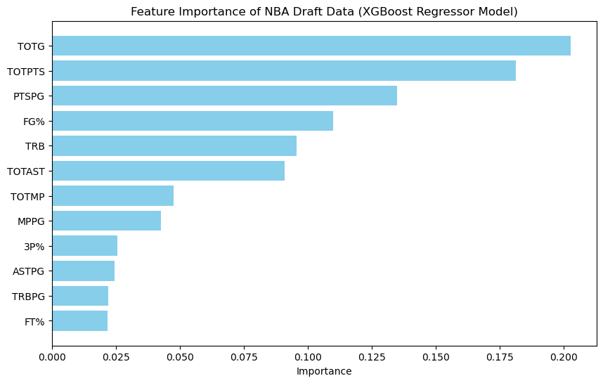

```python
import matplotlib.pyplot as plt
import pandas as pd
# Define feature names and their importance values
features_nba_xgb = [
    'TOTG', 'TOTMP', 'TOTPTS', 'TRB', 'TOTAST', 'FG%', '3P%', 'FT%',
    'MPPG', 'PTSPG', 'TRBPG', 'ASTPG'
]
importances_nba_xgb = [
    0.2028, 0.0475, 0.1815, 0.0956, 0.0911, 0.1099, 0.0256, 0.0218,
    0.0427, 0.1349, 0.0221, 0.0245
]

# Create a DataFrame for easy plotting
df_importances_nba_xgb = pd.DataFrame({
    'Feature': features_nba_xgb,
    'Importance': importances_nba_xgb
})

# Sort the DataFrame by importance
df_importances_nba_xgb = df_importances_nba_xgb.sort_values(by='Importance', ascending=False)

# Plot the bar chart
plt.figure(figsize=(10, 6))
plt.barh(df_importances_nba_xgb['Feature'], df_importances_nba_xgb['Importance'], color='skyblue')
plt.xlabel('Importance')
plt.title('Feature Importance of NBA Draft Data (XGBoost Regressor Model)')
plt.gca().invert_yaxis()  # Invert y-axis to have the highest importance at the top
plt.show()
```

##### Now we merge the NBA Draft data set with the Draft Combine Metrics. Then we will run the merged data set through the above five models to understand the importance of other attributes that may play a vital role in predicting player's success, which is defined by the BPM.

```python
# Load Draft Combine Metrics Data
Draft_Combine = pd.read_csv("C:\\Users\\Sajal Nandi\\Downloads\\SN_30111888_Project\\30111888_Draft-Combine-Metrics.csv")
```

```python
Draft_Combine
```

|  | Draft Year | Player ID | Player Name | Standing Reach_Inches | Height Without Shoes_Inches | Wingspan_Inches | Standing Vertical Leap_Inches | Max Vertical Leap_Inches | Shuttle Run_Secs | Lane Agility_Secs | Three Quarter Sprint_Secs |
| --- | --- | --- | --- | --- | --- | --- | --- | --- | --- | --- | --- |
| 0 | 2000 | 200001 | Kenyon Martin | 110.0 | 79.0 | 81.0 | 28.0 | 34.0 | 3.14 | 11.02 | 3.28 |
| 1 | 2000 | 200002 | Stromile Swift | 108.0 | 81.0 | 88.0 | 31.0 | 39.0 | 3.04 | 11.12 | 3.27 |
| 2 | 2000 | 200003 | Marcus Fizer | 107.0 | 79.0 | 84.0 | 29.0 | 37.0 | 3.00 | 11.23 | 3.23 |
| 3 | 2000 | 200004 | Mike Miller | 106.0 | 80.0 | 81.0 | 30.0 | 36.0 | 3.01 | 11.02 | 3.21 |
| 4 | 2000 | 200005 | DerMarr Johnson | 107.0 | 81.0 | 84.0 | 30.0 | 37.0 | 3.01 | 11.22 | 3.27 |
| ... | ... | ... | ... | ... | ... | ... | ... | ... | ... | ... | ... |
| 418 | 2010 | 201043 | Willie Warren | 98.0 | 76.0 | 80.0 | 35.0 | 38.0 | 3.10 | 11.15 | 3.24 |
| 419 | 2010 | 201044 | Jeremy Evans | 104.0 | 80.0 | 88.0 | 34.0 | 39.0 | 3.03 | 11.02 | 3.20 |
| 420 | 2010 | 201045 | Hamady N'Diaye | 109.0 | 82.0 | 90.0 | 30.0 | 34.0 | 3.17 | 11.52 | 3.32 |
| 421 | 2010 | 201046 | Ryan Reid | 102.0 | 80.0 | 84.0 | 30.0 | 34.0 | 3.20 | 11.40 | 3.32 |
| 422 | 2010 | 201047 | Derrick Caracter | 104.0 | 79.0 | 84.0 | 27.0 | 32.0 | 3.21 | 11.59 | 3.37 |

423 rows × 11 columns

```python
# Checking Empty Cells
empty_cells = Draft_Combine.isna().sum() + (Draft_Combine == '').sum()
```

```python
empty_cells
```

```
Draft Year                       0
Player ID                        0
Player Name                      0
Standing Reach_Inches            0
Height Without Shoes_Inches      0
Wingspan_Inches                  0
Standing Vertical Leap_Inches    0
Max Vertical Leap_Inches         0
Shuttle Run_Secs                 0
Lane Agility_Secs                0
Three Quarter Sprint_Secs        0
dtype: int64
```

```python
# The above outcome shows that there is not empty cell in the data set. So, there is nothing to impute.
```

```python
Draft_Combine_Original = Draft_Combine.drop(["Draft Year", "Player Name"], axis=1)
```

```python
Draft_Combine_Original
```

|  | Player ID | Standing Reach_Inches | Height Without Shoes_Inches | Wingspan_Inches | Standing Vertical Leap_Inches | Max Vertical Leap_Inches | Shuttle Run_Secs | Lane Agility_Secs | Three Quarter Sprint_Secs |
| --- | --- | --- | --- | --- | --- | --- | --- | --- | --- |
| 0 | 200001 | 110.0 | 79.0 | 81.0 | 28.0 | 34.0 | 3.14 | 11.02 | 3.28 |
| 1 | 200002 | 108.0 | 81.0 | 88.0 | 31.0 | 39.0 | 3.04 | 11.12 | 3.27 |
| 2 | 200003 | 107.0 | 79.0 | 84.0 | 29.0 | 37.0 | 3.00 | 11.23 | 3.23 |
| 3 | 200004 | 106.0 | 80.0 | 81.0 | 30.0 | 36.0 | 3.01 | 11.02 | 3.21 |
| 4 | 200005 | 107.0 | 81.0 | 84.0 | 30.0 | 37.0 | 3.01 | 11.22 | 3.27 |
| ... | ... | ... | ... | ... | ... | ... | ... | ... | ... |
| 418 | 201043 | 98.0 | 76.0 | 80.0 | 35.0 | 38.0 | 3.10 | 11.15 | 3.24 |
| 419 | 201044 | 104.0 | 80.0 | 88.0 | 34.0 | 39.0 | 3.03 | 11.02 | 3.20 |
| 420 | 201045 | 109.0 | 82.0 | 90.0 | 30.0 | 34.0 | 3.17 | 11.52 | 3.32 |
| 421 | 201046 | 102.0 | 80.0 | 84.0 | 30.0 | 34.0 | 3.20 | 11.40 | 3.32 |
| 422 | 201047 | 104.0 | 79.0 | 84.0 | 27.0 | 32.0 | 3.21 | 11.59 | 3.37 |

423 rows × 9 columns

```python
X_NBA_Original
```

|  | Player ID | TOTG | TOTMP | TOTPTS | TRB | TOTAST | FG% | 3P% | FT% | MPPG | PTSPG | TRBPG | ASTPG |
| --- | --- | --- | --- | --- | --- | --- | --- | --- | --- | --- | --- | --- | --- |
| 0 | 200001 | 757 | 23134 | 9325 | 5159 | 1439 | 0.483 | 0.234 | 0.629 | 30.6 | 12.3 | 6.8 | 1.9 |
| 1 | 200002 | 547 | 10804 | 4582 | 2535 | 275 | 0.473 | 0.074 | 0.699 | 19.8 | 8.4 | 4.6 | 0.5 |
| 2 | 200003 | 289 | 6032 | 2782 | 1340 | 352 | 0.435 | 0.191 | 0.691 | 20.9 | 9.6 | 4.6 | 1.2 |
| 3 | 200004 | 1032 | 27812 | 10973 | 4376 | 2666 | 0.459 | 0.407 | 0.769 | 26.9 | 10.6 | 4.2 | 2.6 |
| 4 | 200005 | 344 | 5930 | 2121 | 769 | 304 | 0.411 | 0.336 | 0.789 | 17.2 | 6.2 | 2.2 | 0.9 |
| ... | ... | ... | ... | ... | ... | ... | ... | ... | ... | ... | ... | ... | ... |
| 418 | 201043 | 19 | 134 | 37 | 12 | 27 | 0.371 | 0.333 | 0.750 | 7.1 | 1.9 | 0.6 | 1.4 |
| 419 | 201044 | 250 | 2626 | 879 | 641 | 107 | 0.569 | 0.231 | 0.687 | 10.5 | 3.5 | 2.6 | 0.4 |
| 420 | 201045 | 33 | 157 | 20 | 25 | 3 | 0.467 | 0.000 | 0.462 | 4.8 | 0.6 | 0.8 | 0.1 |
| 421 | 201046 | 5 | 17 | 8 | 2 | 0 | 0.800 | 0.000 | 0.000 | 3.4 | 1.6 | 0.4 | 0.0 |
| 422 | 201047 | 41 | 215 | 81 | 43 | 7 | 0.485 | 0.000 | 0.739 | 5.2 | 2.0 | 1.0 | 0.2 |

423 rows × 13 columns

##### The above data sets have the same players' performance statistics and combine metrics with the same player id. So, we will merge the data sets using the common feature "Player ID" in both data set.

```python
# Merging NBA Draft Data set and Draft Combine Metrics Data sets.

NBA_Combine_Merged_Data = pd.merge(X_NBA_Original, Draft_Combine_Original, on='Player ID', how='inner')
```

```python
NBA_Combine_Merged_Data
```

|  | Player ID | TOTG | TOTMP | TOTPTS | TRB | TOTAST | FG% | 3P% | FT% | MPPG | ... | TRBPG | ASTPG | Standing Reach_Inches | Height Without Shoes_Inches | Wingspan_Inches | Standing Vertical Leap_Inches | Max Vertical Leap_Inches | Shuttle Run_Secs | Lane Agility_Secs | Three Quarter Sprint_Secs |
| --- | --- | --- | --- | --- | --- | --- | --- | --- | --- | --- | --- | --- | --- | --- | --- | --- | --- | --- | --- | --- | --- |
| 0 | 200001 | 757 | 23134 | 9325 | 5159 | 1439 | 0.483 | 0.234 | 0.629 | 30.6 | ... | 6.8 | 1.9 | 110.0 | 79.0 | 81.0 | 28.0 | 34.0 | 3.14 | 11.02 | 3.28 |
| 1 | 200002 | 547 | 10804 | 4582 | 2535 | 275 | 0.473 | 0.074 | 0.699 | 19.8 | ... | 4.6 | 0.5 | 108.0 | 81.0 | 88.0 | 31.0 | 39.0 | 3.04 | 11.12 | 3.27 |
| 2 | 200003 | 289 | 6032 | 2782 | 1340 | 352 | 0.435 | 0.191 | 0.691 | 20.9 | ... | 4.6 | 1.2 | 107.0 | 79.0 | 84.0 | 29.0 | 37.0 | 3.00 | 11.23 | 3.23 |
| 3 | 200004 | 1032 | 27812 | 10973 | 4376 | 2666 | 0.459 | 0.407 | 0.769 | 26.9 | ... | 4.2 | 2.6 | 106.0 | 80.0 | 81.0 | 30.0 | 36.0 | 3.01 | 11.02 | 3.21 |
| 4 | 200005 | 344 | 5930 | 2121 | 769 | 304 | 0.411 | 0.336 | 0.789 | 17.2 | ... | 2.2 | 0.9 | 107.0 | 81.0 | 84.0 | 30.0 | 37.0 | 3.01 | 11.22 | 3.27 |
| ... | ... | ... | ... | ... | ... | ... | ... | ... | ... | ... | ... | ... | ... | ... | ... | ... | ... | ... | ... | ... | ... |
| 418 | 201043 | 19 | 134 | 37 | 12 | 27 | 0.371 | 0.333 | 0.750 | 7.1 | ... | 0.6 | 1.4 | 98.0 | 76.0 | 80.0 | 35.0 | 38.0 | 3.10 | 11.15 | 3.24 |
| 419 | 201044 | 250 | 2626 | 879 | 641 | 107 | 0.569 | 0.231 | 0.687 | 10.5 | ... | 2.6 | 0.4 | 104.0 | 80.0 | 88.0 | 34.0 | 39.0 | 3.03 | 11.02 | 3.20 |
| 420 | 201045 | 33 | 157 | 20 | 25 | 3 | 0.467 | 0.000 | 0.462 | 4.8 | ... | 0.8 | 0.1 | 109.0 | 82.0 | 90.0 | 30.0 | 34.0 | 3.17 | 11.52 | 3.32 |
| 421 | 201046 | 5 | 17 | 8 | 2 | 0 | 0.800 | 0.000 | 0.000 | 3.4 | ... | 0.4 | 0.0 | 102.0 | 80.0 | 84.0 | 30.0 | 34.0 | 3.20 | 11.40 | 3.32 |
| 422 | 201047 | 41 | 215 | 81 | 43 | 7 | 0.485 | 0.000 | 0.739 | 5.2 | ... | 1.0 | 0.2 | 104.0 | 79.0 | 84.0 | 27.0 | 32.0 | 3.21 | 11.59 | 3.37 |

423 rows × 21 columns

```python
# The above data set shows that we have successfully merged the data set.
```

```python
# After merging the data sets using "Player ID", we drop the player id feature as it's not necessary for the analysis.
NBA_Combine = NBA_Combine_Merged_Data.drop(["Player ID"], axis=1)
```

```python
NBA_Combine    # We use this final merged data set for the analysis
```

|  | TOTG | TOTMP | TOTPTS | TRB | TOTAST | FG% | 3P% | FT% | MPPG | PTSPG | TRBPG | ASTPG | Standing Reach_Inches | Height Without Shoes_Inches | Wingspan_Inches | Standing Vertical Leap_Inches | Max Vertical Leap_Inches | Shuttle Run_Secs | Lane Agility_Secs | Three Quarter Sprint_Secs |
| --- | --- | --- | --- | --- | --- | --- | --- | --- | --- | --- | --- | --- | --- | --- | --- | --- | --- | --- | --- | --- |
| 0 | 757 | 23134 | 9325 | 5159 | 1439 | 0.483 | 0.234 | 0.629 | 30.6 | 12.3 | 6.8 | 1.9 | 110.0 | 79.0 | 81.0 | 28.0 | 34.0 | 3.14 | 11.02 | 3.28 |
| 1 | 547 | 10804 | 4582 | 2535 | 275 | 0.473 | 0.074 | 0.699 | 19.8 | 8.4 | 4.6 | 0.5 | 108.0 | 81.0 | 88.0 | 31.0 | 39.0 | 3.04 | 11.12 | 3.27 |
| 2 | 289 | 6032 | 2782 | 1340 | 352 | 0.435 | 0.191 | 0.691 | 20.9 | 9.6 | 4.6 | 1.2 | 107.0 | 79.0 | 84.0 | 29.0 | 37.0 | 3.00 | 11.23 | 3.23 |
| 3 | 1032 | 27812 | 10973 | 4376 | 2666 | 0.459 | 0.407 | 0.769 | 26.9 | 10.6 | 4.2 | 2.6 | 106.0 | 80.0 | 81.0 | 30.0 | 36.0 | 3.01 | 11.02 | 3.21 |
| 4 | 344 | 5930 | 2121 | 769 | 304 | 0.411 | 0.336 | 0.789 | 17.2 | 6.2 | 2.2 | 0.9 | 107.0 | 81.0 | 84.0 | 30.0 | 37.0 | 3.01 | 11.22 | 3.27 |
| ... | ... | ... | ... | ... | ... | ... | ... | ... | ... | ... | ... | ... | ... | ... | ... | ... | ... | ... | ... | ... |
| 418 | 19 | 134 | 37 | 12 | 27 | 0.371 | 0.333 | 0.750 | 7.1 | 1.9 | 0.6 | 1.4 | 98.0 | 76.0 | 80.0 | 35.0 | 38.0 | 3.10 | 11.15 | 3.24 |
| 419 | 250 | 2626 | 879 | 641 | 107 | 0.569 | 0.231 | 0.687 | 10.5 | 3.5 | 2.6 | 0.4 | 104.0 | 80.0 | 88.0 | 34.0 | 39.0 | 3.03 | 11.02 | 3.20 |
| 420 | 33 | 157 | 20 | 25 | 3 | 0.467 | 0.000 | 0.462 | 4.8 | 0.6 | 0.8 | 0.1 | 109.0 | 82.0 | 90.0 | 30.0 | 34.0 | 3.17 | 11.52 | 3.32 |
| 421 | 5 | 17 | 8 | 2 | 0 | 0.800 | 0.000 | 0.000 | 3.4 | 1.6 | 0.4 | 0.0 | 102.0 | 80.0 | 84.0 | 30.0 | 34.0 | 3.20 | 11.40 | 3.32 |
| 422 | 41 | 215 | 81 | 43 | 7 | 0.485 | 0.000 | 0.739 | 5.2 | 2.0 | 1.0 | 0.2 | 104.0 | 79.0 | 84.0 | 27.0 | 32.0 | 3.21 | 11.59 | 3.37 |

423 rows × 20 columns

```python
# Checking NAN values columnwise
nan_count_per_column = NBA_Combine.isna().sum()
```

```python
nan_count_per_column
```

```
TOTG                             0
TOTMP                            0
TOTPTS                           0
TRB                              0
TOTAST                           0
FG%                              0
3P%                              0
FT%                              0
MPPG                             0
PTSPG                            0
TRBPG                            0
ASTPG                            0
Standing Reach_Inches            0
Height Without Shoes_Inches      0
Wingspan_Inches                  0
Standing Vertical Leap_Inches    0
Max Vertical Leap_Inches         0
Shuttle Run_Secs                 0
Lane Agility_Secs                0
Three Quarter Sprint_Secs        0
dtype: int64
```

```python
# From the above outcome, we can say that there is no NAN values in the merged data set.
```

```python
# Our target variable
y_nba_o
```

|  | BPM |
| --- | --- |
| 0 | 0.1 |
| 1 | -1.6 |
| 2 | -3.7 |
| 3 | 0.8 |
| 4 | -1.6 |
| ... | ... |
| 418 | -2.7 |
| 419 | 0.9 |
| 420 | -7.3 |
| 421 | -2.0 |
| 422 | -7.1 |

423 rows × 1 columns

```python
y_NBA_Combine = pd.DataFrame(y_nba_o)
```

```python
y_NBA_Combine # Target variable for analysing the merged data set
```

|  | BPM |
| --- | --- |
| 0 | 0.1 |
| 1 | -1.6 |
| 2 | -3.7 |
| 3 | 0.8 |
| 4 | -1.6 |
| ... | ... |
| 418 | -2.7 |
| 419 | 0.9 |
| 420 | -7.3 |
| 421 | -2.0 |
| 422 | -7.1 |

423 rows × 1 columns

```python
X_NBA_Combine = pd.DataFrame(NBA_Combine) # Renaming the merged data set for the analysis
```

```python
X_NBA_Combine
```

|  | TOTG | TOTMP | TOTPTS | TRB | TOTAST | FG% | 3P% | FT% | MPPG | PTSPG | TRBPG | ASTPG | Standing Reach_Inches | Height Without Shoes_Inches | Wingspan_Inches | Standing Vertical Leap_Inches | Max Vertical Leap_Inches | Shuttle Run_Secs | Lane Agility_Secs | Three Quarter Sprint_Secs |
| --- | --- | --- | --- | --- | --- | --- | --- | --- | --- | --- | --- | --- | --- | --- | --- | --- | --- | --- | --- | --- |
| 0 | 757 | 23134 | 9325 | 5159 | 1439 | 0.483 | 0.234 | 0.629 | 30.6 | 12.3 | 6.8 | 1.9 | 110.0 | 79.0 | 81.0 | 28.0 | 34.0 | 3.14 | 11.02 | 3.28 |
| 1 | 547 | 10804 | 4582 | 2535 | 275 | 0.473 | 0.074 | 0.699 | 19.8 | 8.4 | 4.6 | 0.5 | 108.0 | 81.0 | 88.0 | 31.0 | 39.0 | 3.04 | 11.12 | 3.27 |
| 2 | 289 | 6032 | 2782 | 1340 | 352 | 0.435 | 0.191 | 0.691 | 20.9 | 9.6 | 4.6 | 1.2 | 107.0 | 79.0 | 84.0 | 29.0 | 37.0 | 3.00 | 11.23 | 3.23 |
| 3 | 1032 | 27812 | 10973 | 4376 | 2666 | 0.459 | 0.407 | 0.769 | 26.9 | 10.6 | 4.2 | 2.6 | 106.0 | 80.0 | 81.0 | 30.0 | 36.0 | 3.01 | 11.02 | 3.21 |
| 4 | 344 | 5930 | 2121 | 769 | 304 | 0.411 | 0.336 | 0.789 | 17.2 | 6.2 | 2.2 | 0.9 | 107.0 | 81.0 | 84.0 | 30.0 | 37.0 | 3.01 | 11.22 | 3.27 |
| ... | ... | ... | ... | ... | ... | ... | ... | ... | ... | ... | ... | ... | ... | ... | ... | ... | ... | ... | ... | ... |
| 418 | 19 | 134 | 37 | 12 | 27 | 0.371 | 0.333 | 0.750 | 7.1 | 1.9 | 0.6 | 1.4 | 98.0 | 76.0 | 80.0 | 35.0 | 38.0 | 3.10 | 11.15 | 3.24 |
| 419 | 250 | 2626 | 879 | 641 | 107 | 0.569 | 0.231 | 0.687 | 10.5 | 3.5 | 2.6 | 0.4 | 104.0 | 80.0 | 88.0 | 34.0 | 39.0 | 3.03 | 11.02 | 3.20 |
| 420 | 33 | 157 | 20 | 25 | 3 | 0.467 | 0.000 | 0.462 | 4.8 | 0.6 | 0.8 | 0.1 | 109.0 | 82.0 | 90.0 | 30.0 | 34.0 | 3.17 | 11.52 | 3.32 |
| 421 | 5 | 17 | 8 | 2 | 0 | 0.800 | 0.000 | 0.000 | 3.4 | 1.6 | 0.4 | 0.0 | 102.0 | 80.0 | 84.0 | 30.0 | 34.0 | 3.20 | 11.40 | 3.32 |
| 422 | 41 | 215 | 81 | 43 | 7 | 0.485 | 0.000 | 0.739 | 5.2 | 2.0 | 1.0 | 0.2 | 104.0 | 79.0 | 84.0 | 27.0 | 32.0 | 3.21 | 11.59 | 3.37 |

423 rows × 20 columns

```python
skewness_per_column = X_NBA_Combine.skew()
```

```python
skewness_per_column
```

```
TOTG                             0.517557
TOTMP                            1.044943
TOTPTS                           1.823226
TRB                              1.589068
TOTAST                           2.941461
FG%                              0.102526
3P%                             -0.723551
FT%                             -2.237356
MPPG                             0.152056
PTSPG                            1.172282
TRBPG                            1.206813
ASTPG                            2.027343
Standing Reach_Inches            0.049747
Height Without Shoes_Inches     -0.461274
Wingspan_Inches                  0.017074
Standing Vertical Leap_Inches   -2.334136
Max Vertical Leap_Inches         0.072883
Shuttle Run_Secs                 0.693340
Lane Agility_Secs                0.530205
Three Quarter Sprint_Secs        1.556095
dtype: float64
```

#### Considering the above outcomes, we can see that the features are not normally distributed. We don't use any kind of transformation techniques to reduce the skewness of the features. This is because the models we use for our analysis are not sensitive to skewded or non-distributed data sets.

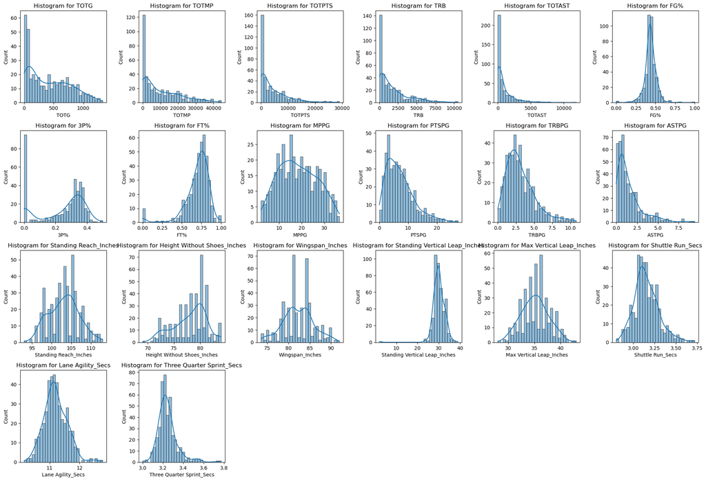

```python
# Set up the plot grid
num_columns = X_NBA_Combine.select_dtypes(include=['float64', 'int64']).columns  # Only numeric features
plt.figure(figsize=(20, 20))

for i, column in enumerate(num_columns, 1):
    plt.subplot(6, 6, i)  # Adjust 6x6 grid based on the number of features
    sns.histplot(X_NBA_Combine[column], kde=True, bins=30, edgecolor='black')
    plt.title(f'Histogram for {column}')

plt.tight_layout()
plt.show()
```

```python
# Spliting merged data set and the target variable
from sklearn.model_selection import train_test_split
X_NBA_Combine_train, X_NBA_Combine_test, y_NBA_Combine_train, y_NBA_Combine_test = train_test_split(X_NBA_Combine, y_NBA_Combine, test_size=0.2, random_state=42)
```

### Random Forest Regressor for the merged data set "X_NAB_Combine" (NBA Draft data and Draft Combine Metrics)

```python
from sklearn.ensemble import RandomForestRegressor
from sklearn.model_selection import train_test_split
from sklearn.metrics import mean_squared_error, r2_score
import pandas as pd
import numpy as np
```

```python
# Initializing the random forest regressor with 100 trees
rf_nba_combine = RandomForestRegressor(n_estimators=100, random_state=42)
```

```python
# Fitting the model on training data
rf_nba_combine.fit(X_NBA_Combine_train, y_NBA_Combine_train)
```

```
C:\Users\Sajal Nandi\AppData\Local\Temp\ipykernel_5836\755896038.py:2: DataConversionWarning: A column-vector y was passed when a 1d array was expected. Please change the shape of y to (n_samples,), for example using ravel().
  rf_nba_combine.fit(X_NBA_Combine_train, y_NBA_Combine_train)
```

```
RandomForestRegressor(random_state=42)
```

```python
# Predicting the BPM values for the test set
y_pred_rf_nba_combine = rf_nba_combine.predict(X_NBA_Combine_test)   #rf means Random Forest
```

```python
# Evaluating the model
mse_rf_nba_combine = mean_squared_error(y_NBA_Combine_test, y_pred_rf_nba_combine)
r2_rf_nba_combine = r2_score(y_NBA_Combine_test, y_pred_rf_nba_combine)

print(f'Mean Squared Error: {mse_rf_nba_combine}')
print(f'R-squared: {r2_rf_nba_combine}')
```

```
Mean Squared Error: 3.1480629294117635
R-squared: 0.7566017376651024
```

```python
# Hyperparameter Tuning for the Random Forest Regressor Model
from sklearn.model_selection import GridSearchCV
```

```python
param_grid = {
    'n_estimators': [100, 200, 300],
    'max_depth': [10, 20, 30],
    'min_samples_split': [2, 5, 10]
}

grid_search = GridSearchCV(estimator=rf_nba_combine, param_grid=param_grid, cv=5)
grid_search.fit(X_NBA_Combine_train, y_NBA_Combine_train)

print(grid_search.best_params_)
```

[output not shown]

[output cut: 246 more lines]

```
{'max_depth': 10, 'min_samples_split': 10, 'n_estimators': 200}
```

```python
# Initializing the random forest regressor with new parameters
rf_nba_combine_tune = RandomForestRegressor(n_estimators=200, max_depth=10, min_samples_split=10, random_state=42)
```

```python
# Fitting the model on training data
rf_nba_combine_tune.fit(X_NBA_Combine_train, y_NBA_Combine_train)
```

```
C:\Users\Sajal Nandi\AppData\Local\Temp\ipykernel_5836\1754509678.py:2: DataConversionWarning: A column-vector y was passed when a 1d array was expected. Please change the shape of y to (n_samples,), for example using ravel().
  rf_nba_combine_tune.fit(X_NBA_Combine_train, y_NBA_Combine_train)
```

```
RandomForestRegressor(max_depth=10, min_samples_split=10, n_estimators=200,
                      random_state=42)
```

```python
# Predicting the BPM values for the test set
y_pred_rf_nba_combine_tune = rf_nba_combine_tune.predict(X_NBA_Combine_test)   #rf means Random Forest
```

```python
# Evaluating the model
mse_rf_nba_combine_tune = mean_squared_error(y_NBA_Combine_test, y_pred_rf_nba_combine_tune)
r2_rf_nba_combine_tune = r2_score(y_NBA_Combine_test, y_pred_rf_nba_combine_tune)

print(f'Mean Squared Error: {mse_rf_nba_combine_tune}')
print(f'R-squared: {r2_rf_nba_combine_tune}')
```

```
Mean Squared Error: 3.062876815998897
R-squared: 0.763188058346954
```

```python
# The model performed slightly better with hyperparameters.
```

#### XGBoost Model for NBA data set for the merged data set "X_NAB_Combine" (NBA Draft data and Draft Combine Metrics)

```python
# Names of split data set = X_NBA_Combine_train, X_NBA_Combine_test, y_NBA_Combine_train, y_NBA_Combine_test
```

```python
import xgboost as xgb
from sklearn.model_selection import train_test_split
from sklearn.preprocessing import StandardScaler
from sklearn.metrics import mean_squared_error, r2_score
import pandas as pd
import numpy as np
```

```python
# Feature Scaling

scaler = StandardScaler()

# Scale the training data
X_NBA_Combine_train_scaled = scaler.fit_transform(X_NBA_Combine_train)

# Scale the test data
X_NBA_Combine_test_scaled = scaler.transform(X_NBA_Combine_test)
```

```python
# Initialize the XGBoost regressor
xgb_model_nba_combine = xgb.XGBRegressor(
    n_estimators=100,  # Number of boosting rounds (trees)
    learning_rate=0.1, # Shrinkage rate
    max_depth=3,       # Maximum depth of trees
    subsample=0.8,     # Fraction of samples used for fitting individual base learners
    random_state=42
)
```

```python
xgb_model_nba_combine.fit(X_NBA_Combine_train_scaled, y_NBA_Combine_train)
```

```
XGBRegressor(base_score=None, booster=None, callbacks=None,
             colsample_bylevel=None, colsample_bynode=None,
             colsample_bytree=None, device=None, early_stopping_rounds=None,
             enable_categorical=False, eval_metric=None, feature_types=None,
             gamma=None, grow_policy=None, importance_type=None,
             interaction_constraints=None, learning_rate=0.1, max_bin=None,
             max_cat_threshold=None, max_cat_to_onehot=None,
             max_delta_step=None, max_depth=3, max_leaves=None,
             min_child_weight=None, missing=nan, monotone_constraints=None,
             multi_strategy=None, n_estimators=100, n_jobs=None,
             num_parallel_tree=None, random_state=42, ...)
```

```python
# Predict BPM values for the test set
y_pred_xgb_nba_combine = xgb_model_nba_combine.predict(X_NBA_Combine_test_scaled)
```

```python
# Evaluate the model
mse_xgb_nba_combine = mean_squared_error(y_NBA_Combine_test, y_pred_xgb_nba_combine)
r2_xgb_nba_combine = r2_score(y_NBA_Combine_test, y_pred_xgb_nba_combine)
```

```python
print(f'Mean Squared Error: {mse_xgb_nba_combine}')
print(f'R-squared: {r2_xgb_nba_combine}')
```

```
Mean Squared Error: 3.1476026258720244
R-squared: 0.7566373268779711
```

```python
# Hyperparameter Tuning

from sklearn.model_selection import GridSearchCV

# Define the parameter grid
param_grid = {
    'n_estimators': [100, 200, 300],
    'learning_rate': [0.01, 0.1, 0.2],
    'max_depth': [3, 5, 7],
    'subsample': [0.8, 1.0]
}

# Initialize GridSearchCV with XGBRegressor
grid_search = GridSearchCV(estimator=xgb.XGBRegressor(random_state=42), param_grid=param_grid, cv=5, scoring='r2')

# Fit the grid search to the scaled training data
grid_search.fit(X_NBA_Combine_train_scaled, y_NBA_Combine_train)

# Print the best parameters
print(f'Best parameters: {grid_search.best_params_}')
```

```
Best parameters: {'learning_rate': 0.2, 'max_depth': 5, 'n_estimators': 300, 'subsample': 0.8}
```

```python
# Use the best model for prediction
best_model_xgb_nba_combine = grid_search.best_estimator_
y_pred_best_xgb_nba_combine_tune = best_model_xgb_nba_combine.predict(X_NBA_Combine_test_scaled)
```

```python
# Evaluate the best model
mse_best_xgb_nba_combine_tune = mean_squared_error(y_NBA_Combine_test, y_pred_best_xgb_nba_combine_tune)
r2_best_xgb_nba_combine_tune = r2_score(y_NBA_Combine_test, y_pred_best_xgb_nba_combine_tune)

print(f'Best Mean Squared Error: {mse_best_xgb_nba_combine_tune}')
print(f'Best R-squared: {r2_best_xgb_nba_combine_tune}')
```

```
Best Mean Squared Error: 3.0769412614826686
Best R-squared: 0.7621006399349931
```

```python
# The model with the tuned hyparparameters performed slightly better.
```

#### Artificial Neural Network (ANN) for the merged data set "X_NAB_Combine" (NBA Draft data and Draft Combine Metrics)

```python
# Names of split data set = X_NBA_Combine_train, X_NBA_Combine_test, y_NBA_Combine_train, y_NBA_Combine_test
```

```python
import numpy as np
import pandas as pd
from sklearn.model_selection import train_test_split
from sklearn.preprocessing import StandardScaler
from sklearn.metrics import mean_squared_error, r2_score
import tensorflow as tf
from tensorflow.keras.models import Sequential
from tensorflow.keras.layers import Dense
from tensorflow.keras.optimizers import Adam
```

```python
# Feature Scaling

scaler = StandardScaler()

# Scale the training data
X_NBA_Combine_train_scaled = scaler.fit_transform(X_NBA_Combine_train)

# Scale the test data
X_NBA_Combine_test_scaled = scaler.transform(X_NBA_Combine_test)
```

```python
# Initialize the model
model_nba_combine_ann = Sequential()

# Input layer and first hidden layer with 64 neurons and ReLU activation
model_nba_combine_ann.add(Dense(64, input_dim=X_NBA_Combine_train_scaled.shape[1], activation='relu'))

# Additional hidden layers
model_nba_combine_ann.add(Dense(128, activation='relu'))
model_nba_combine_ann.add(Dense(64, activation='relu'))

# Output layer with a single neuron (since this is a regression problem)
model_nba_combine_ann.add(Dense(1, activation='linear'))

# Compile the model with mean squared error loss and the Adam optimizer
model_nba_combine_ann.compile(optimizer=Adam(learning_rate=0.001), loss='mean_squared_error', metrics=['mse'])
```

```python
# Train the model
history = model_nba_combine_ann.fit(X_NBA_Combine_train_scaled, y_NBA_Combine_train, validation_split=0.2, epochs=100, batch_size=32, verbose=1)
```

```python
# Predict BPM values for the test set
y_pred_nba_combine_ann = model_nba_combine_ann.predict(X_NBA_Combine_test_scaled)

# Evaluate the model's performance
mse_nba_combine_ann = mean_squared_error(y_NBA_Combine_test, y_pred_nba_combine_ann)
r2_nba_combine_ann = r2_score(y_NBA_Combine_test, y_pred_nba_combine_ann)

print(f'Mean Squared Error: {mse_nba_combine_ann}')
print(f'R-squared: {r2_nba_combine_ann}')
```

```
Mean Squared Error: 3.921755693596234
R-squared: 0.696782261814036
```

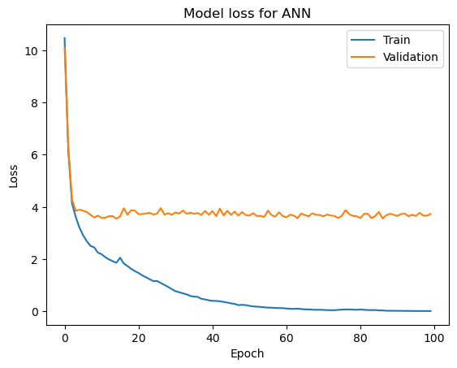

```python
# Visualizing Training history
import matplotlib.pyplot as plt

# Plot training & validation loss values
plt.plot(history.history['loss'])
plt.plot(history.history['val_loss'])
plt.title('Model loss for ANN')
plt.xlabel('Epoch')
plt.ylabel('Loss')
plt.legend(['Train', 'Validation'], loc='upper right')
plt.show()
```

```python
# The model overfits
```

```python
# We now use L2 Regularization to check whether the model with L2 Regularization performs better or not.

from keras.regularizers import l2

# Define the neural network architecture with L2 regularization
model_nba_combine_ann_l2 = Sequential()

# Input layer and first hidden layer with 64 neurons, ReLU activation, and L2 regularization
model_nba_combine_ann_l2.add(Dense(64, input_dim=X_NBA_Combine_train_scaled.shape[1], activation='relu',
                kernel_regularizer=l2(0.01)))  # L2 regularization with factor 0.01

# Additional hidden layers with L2 regularization
model_nba_combine_ann_l2.add(Dense(128, activation='relu', kernel_regularizer=l2(0.01)))
model_nba_combine_ann_l2.add(Dense(64, activation='relu', kernel_regularizer=l2(0.01)))

# Output layer with 1 neuron (for regression)
model_nba_combine_ann_l2.add(Dense(1, activation='linear'))

# Compile the model
model_nba_combine_ann_l2.compile(optimizer=Adam(learning_rate=0.001), loss='mean_squared_error', metrics=['mse'])
```

```python
# Train the model
history_nba_combine_ann_l2 = model_nba_combine_ann_l2.fit(X_NBA_Combine_train_scaled, y_NBA_Combine_train, validation_split=0.2, epochs=100, batch_size=32, verbose=1)
```

```python
# Predict BPM values for the test set
y_pred_nba_combine_ann_l2 = model_nba_combine_ann_l2.predict(X_NBA_Combine_test_scaled)

# Evaluate the model's performance
mse_nba_combine_ann_l2 = mean_squared_error(y_NBA_Combine_test, y_pred_nba_combine_ann_l2)
r2_nba_combine_ann_l2 = r2_score(y_NBA_Combine_test, y_pred_nba_combine_ann_l2)

print(f'Mean Squared Error: {mse_nba_combine_ann_l2}')
print(f'R-squared: {r2_nba_combine_ann_l2}')
```

```
Mean Squared Error: 3.8463748221752514
R-squared: 0.7026104722178814
```

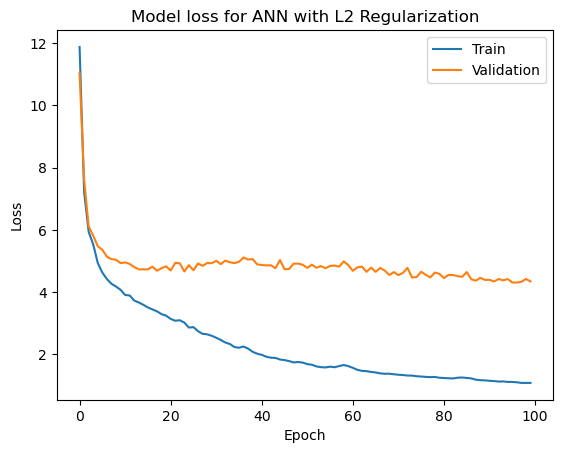

```python
# Visualizing Training history
import matplotlib.pyplot as plt

# Plot training & validation loss values
plt.plot(history_nba_combine_ann_l2.history['loss'])
plt.plot(history_nba_combine_ann_l2.history['val_loss'])
plt.title('Model loss for ANN with L2 Regularization')
plt.xlabel('Epoch')
plt.ylabel('Loss')
plt.legend(['Train', 'Validation'], loc='upper right')
plt.show()
```

```python
# The above model overfits
```